# Human Freedom Index

Dimitri Angelov, Jeeda AbuKhader, Simona Rahi

12/7/2019

```r
library(tidyverse)
library(pastecs)
library(ggplot2)
library(corrplot)
library(pastecs)
library(Hmisc)
library(ggpubr)
library(PerformanceAnalytics)
library(data.table)
library(GGally)

#Import data set
human_freedom_index <- ("~/working/data_science_folders/statistical_inference_data_science_I/project_stats/project_group_stats/hfi_cc_2018.csv")

#Have the variables read in as factors to make the interpretation easier to understand
human_freedom_read <- fread(human_freedom_index)
human_freedom_read[,1:4] <- lapply(human_freedom_read[,1:4], as.factor)

#Only use the year 2016
human_freedom <- subset(human_freedom_read, year == 2016)
freedom_2016 <- subset(human_freedom, year == 2016 )
```

## Summary Statistics

```r
#Distribution of variables
variable_stats <- human_freedom %>%
  select(pf_rol_criminal, pf_ss_homicide, pf_movement, pf_religion, pf_identity, pf_score, pf_rank, hf_score, hf_rank) %>%
  na.omit()
summary(variable_stats)
```

```
##  pf_rol_criminal pf_ss_homicide   pf_movement      pf_religion
##  Min.   :1.429   Min.   :0.000   Min.   : 0.000   Min.   :3.666
##  1st Qu.:3.671   1st Qu.:6.934   1st Qu.: 6.667   1st Qu.:6.876
##  Median :4.506   Median :8.723   Median :10.000   Median :7.913
##  Mean   :4.883   Mean   :7.487   Mean   : 8.222   Mean   :7.514
##  3rd Qu.:6.028   3rd Qu.:9.519   3rd Qu.:10.000   3rd Qu.:8.533
##  Max.   :8.464   Max.   :9.887   Max.   :10.000   Max.   :9.731
##   pf_identity        pf_score        pf_rank          hf_score
##  Min.   : 0.000   Min.   :3.895   Min.   :  1.00   Min.   :4.201
##  1st Qu.: 6.250   1st Qu.:6.381   1st Qu.: 37.00   1st Qu.:6.482
##  Median : 9.250   Median :7.238   Median : 72.00   Median :7.034
##  Mean   : 7.508   Mean   :7.281   Mean   : 72.93   Mean   :7.102
##  3rd Qu.: 9.250   3rd Qu.:8.296   3rd Qu.:108.00   3rd Qu.:7.858
##  Max.   :10.000   Max.   :9.399   Max.   :158.00   Max.   :8.887
##     hf_rank
##  Min.   :  1.00
##  1st Qu.: 37.00
##  Median : 70.00
##  Mean   : 72.38
##  3rd Qu.:106.00
##  Max.   :161.00
```

*Number of rows and columns*

```r
dim(human_freedom)
```

```
## [1] 162 123
```

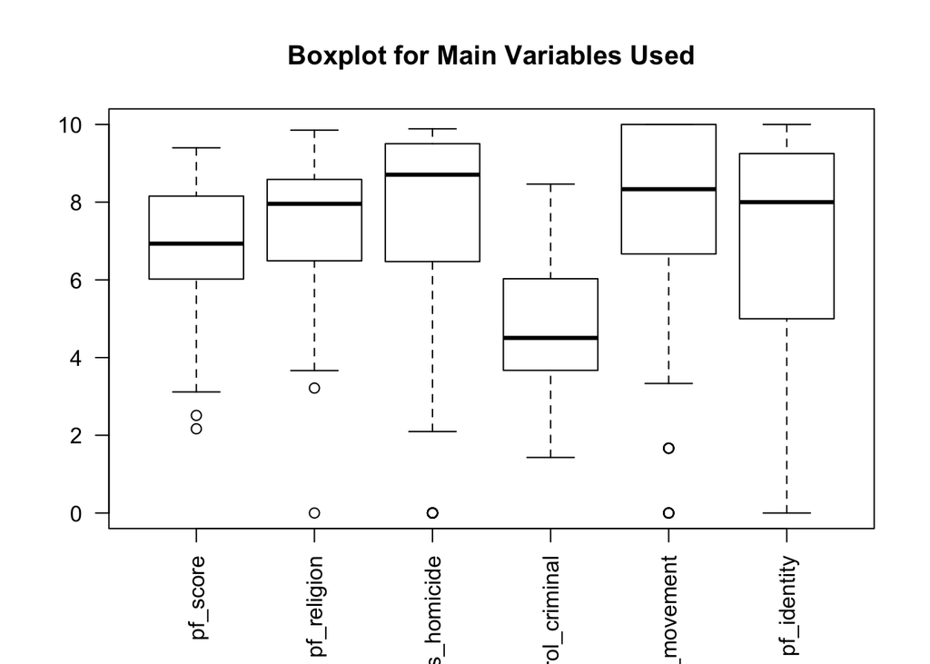

```r
boxpl <- freedom_2016 %>%
  select(pf_score, pf_religion, pf_ss_homicide, pf_rol_criminal, pf_movement, pf_identity)
boxplot(boxpl, main = "Boxplot for Main Variables Used", use.cols = TRUE, las = 2)
```

## Correlation Matrix pf_score

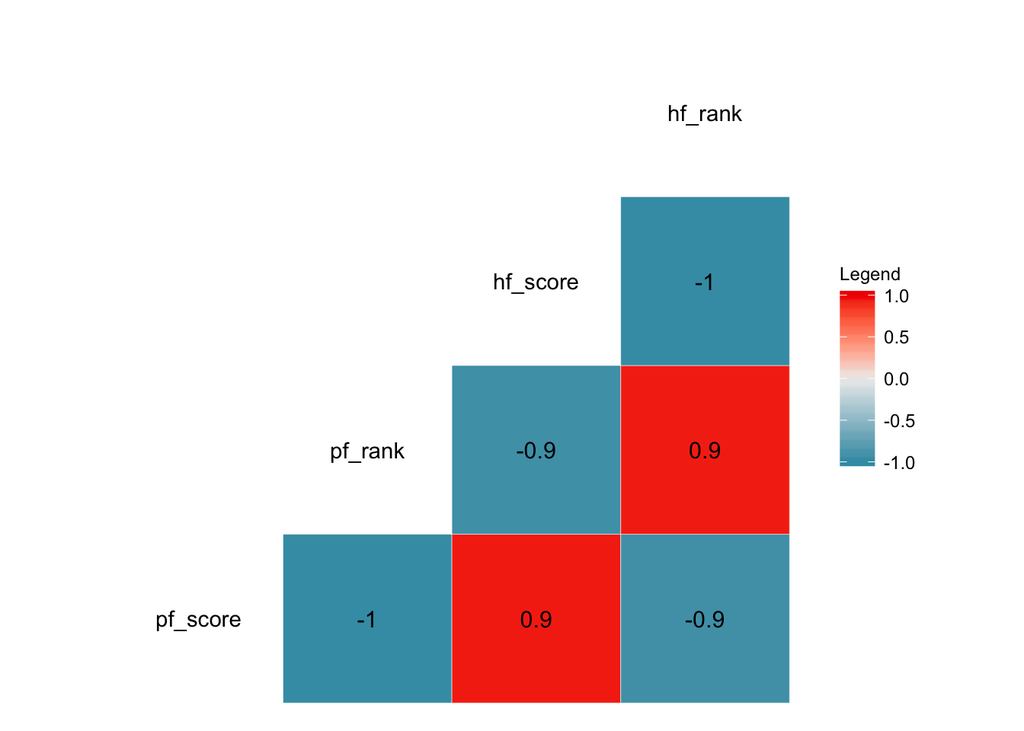

```r
#Create personal freedom index
personal_freedom_score <- human_freedom %>%
  select(pf_score, pf_rank, hf_score, hf_rank) %>%
  na.omit()

#Create matrix table for personal freedom index
personal_freedom_score %>%
  ggcorr(label = T, low = "#3B9AB2", high = "#F21A00", name = "Legend")
```

## Correlation Matrix of all Variables

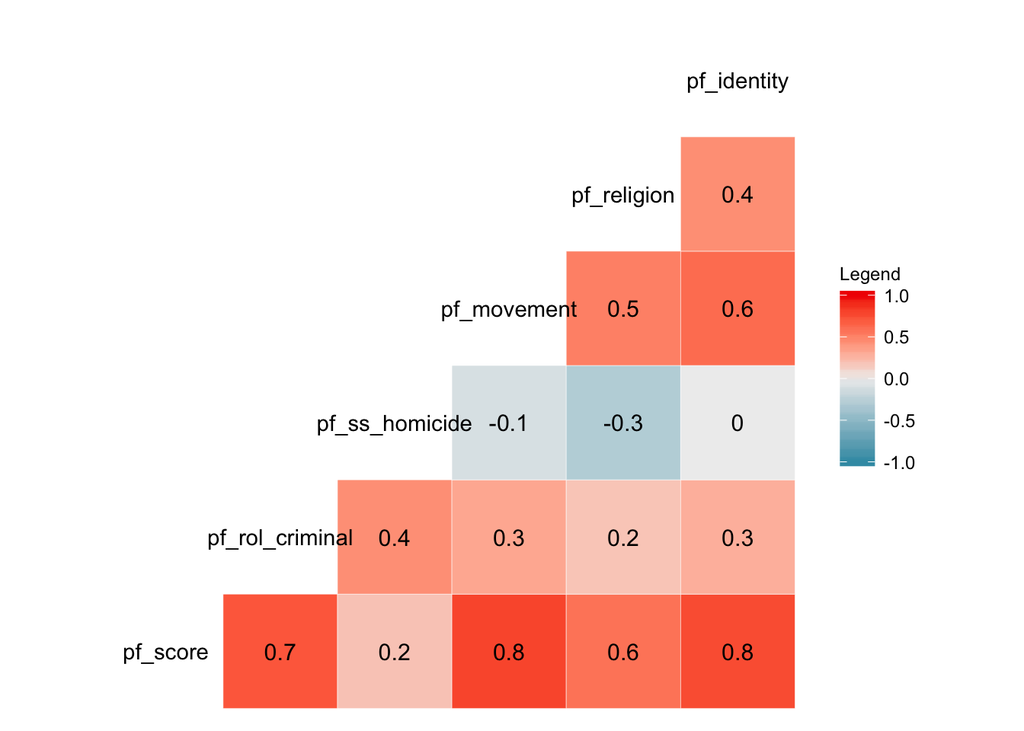

```r
#Create a correlation matrix to see which variables are the most related to each other
matrix_correlation_multiple <- human_freedom %>%
  select(pf_score, pf_rol_criminal, pf_ss_homicide, pf_movement, pf_religion, pf_identity)

#Create matrix table
matrix_correlation_multiple %>%
  ggcorr(label = T, low = "#3B9AB2", high = "#F21A00", name = "Legend")
```

## Is the Average Population Personal Freedom Score 7.5?

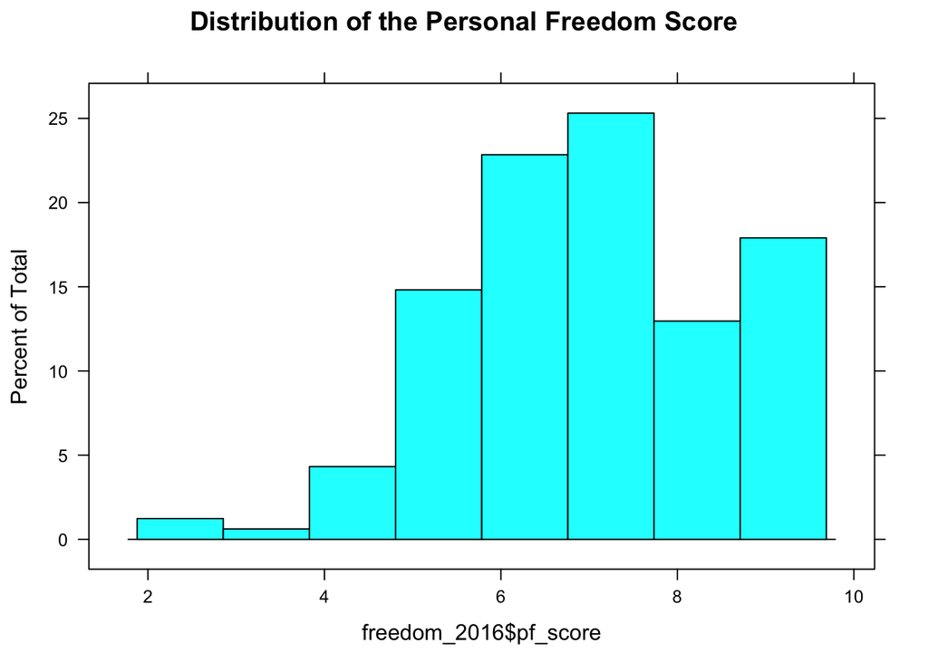

```r
#Number 2
#Create a categorical variable from personal freedom score for low, medium, and high freedom levels
#Freedom levels for 2016
freedom_levels_2016 <- cut(freedom_2016$pf_score, c(0, 3.5, 7.5, 10))
levels(freedom_levels_2016) <- c("Low Freedom", "Medium Freedom", "High Freedom")
low_freedom_2016 <- subset(freedom_2016, freedom_levels_2016 == "Low Freedom")
med_freedom_2016 <- subset(freedom_2016, freedom_levels_2016 == "Medium Freedom")
high_freedom_2016 <- subset(freedom_2016, freedom_levels_2016 == "High Freedom")

#Checking assumption of normality with a histogram
histogram(freedom_2016$pf_score, main = "Distribution of the Personal Freedom Score")
```

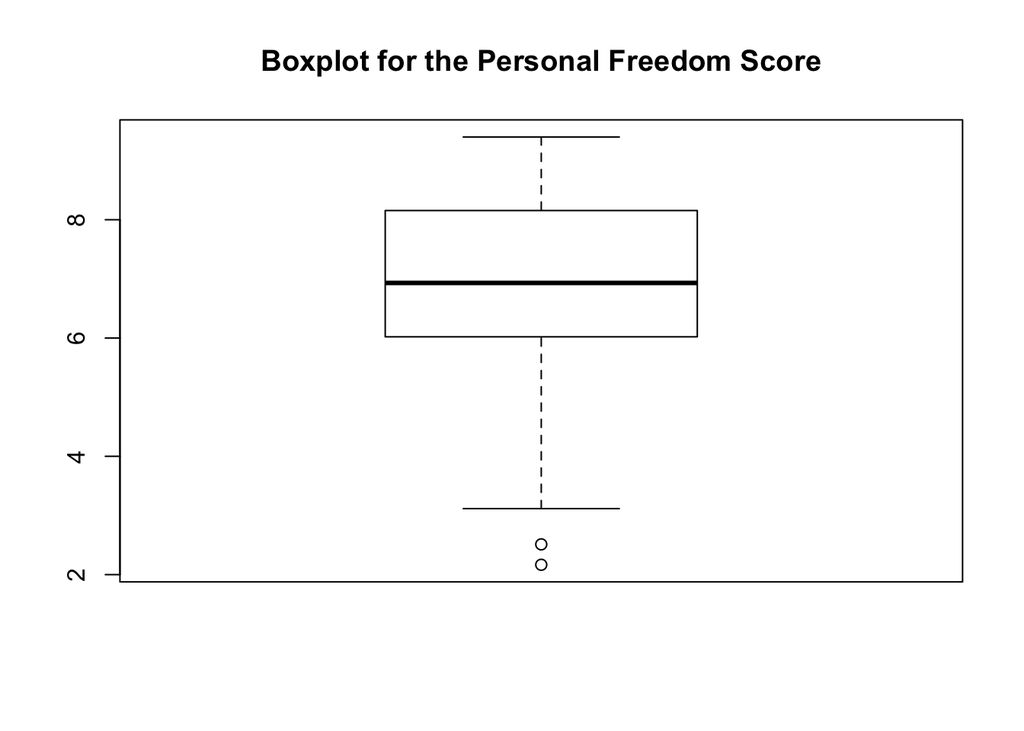

```r
#Now check with a boxplot
boxplot(freedom_2016$pf_score, main = "Boxplot for the Personal Freedom Score")
```

*Which Countries are the Outliers?*

```r
#Checking wich countries are outliers
freedom_2016 %>%
  select(countries, pf_score) %>%
  filter(pf_score < 3)
```

```
##     countries pf_score
## 1       Syria 2.511654
## 2 Yemen, Rep. 2.166555
```

```r
#Removing outliers
new_freedom_2016 <- freedom_2016[-which(freedom_2016$pf_score < 3),]
```

$$H_0: \mu=7.5 \\ H_a: \mu\neq7.5$$
Where $\mu$ is the population mean for personal freedom score in 2016.

*Run a One Sample t-test*

```r
#Running the t-test
t.test(new_freedom_2016$pf_score, mu=7.5)
```

```
##
##  One Sample t-test
##
## data:  new_freedom_2016$pf_score
## t = -4.1171, df = 159, p-value = 6.149e-05
## alternative hypothesis: true mean is not equal to 7.5
## 95 percent confidence interval:
##  6.823403 7.262096
## sample estimates:
## mean of x
##  7.042749
```

```r
Cohen <- abs(mean(new_freedom_2016$pf_score)-7.5)/sd(new_freedom_2016$pf_score)
print("Cohen's d is 0.33")
```

```
## [1] "Cohen's d is 0.33"
```

## Do Most Countries Fall Under the Category of “High Levels of Personal Freedom”?

*Proportion Testing*
$$H_0: p= 0.5\\ H_a: p\neq0.5$$
Where p is the proportion of countries that fall under high levels of freedom.

*Hypothesis Testing*

```r
#Number 3
#Hypothesis Test
x <- nrow(high_freedom_2016)
n <- sum(nrow(low_freedom_2016),nrow(med_freedom_2016), nrow(high_freedom_2016))
prop.test(x, n, p = 0.5, correct = FALSE)
```

```
##
##  1-sample proportions test without continuity correction
##
## data:  x out of n, null probability 0.5
## X-squared = 10.889, df = 1, p-value = 0.0009674
## alternative hypothesis: true p is not equal to 0.5
## 95 percent confidence interval:
##  0.2998160 0.4469301
## sample estimates:
##         p
## 0.3703704
```

## Is there a Significant Difference in Religious Freedom between Latin America & Carribean and Middle East & North Africa Regions?

*Checking for Assumptions*

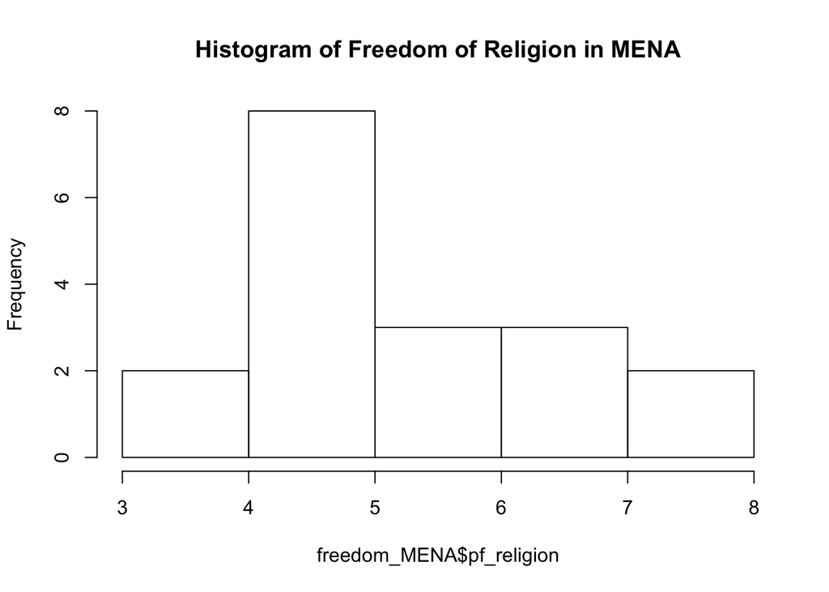

```r
#Number 4
freedom_MENA <- subset(freedom_2016, freedom_2016$region == "Middle East & North Africa")
freedom_latin_america <- subset(freedom_2016, freedom_2016$region == "Latin America & the Caribbean")
df <- freedom_2016 %>%
  filter(region == "Middle East & North Africa" | region == "Latin America & the Caribbean")

#Checking for assumptions
#Check histogram for Middle East
hist(freedom_MENA$pf_religion, main = "Histogram of Freedom of Religion in MENA")
```

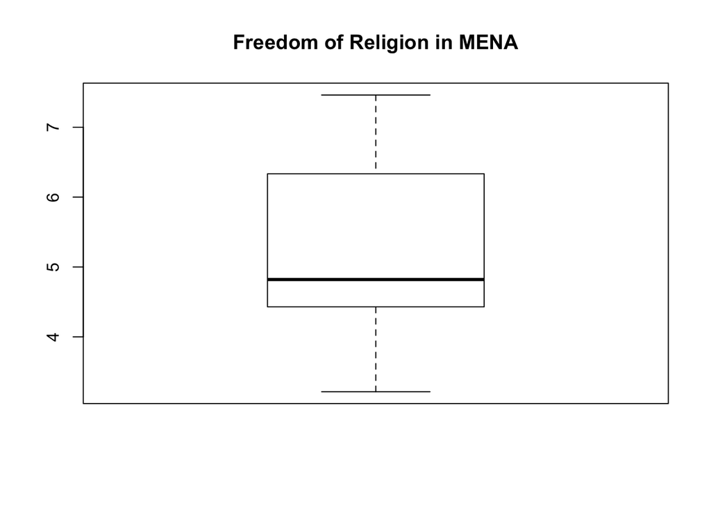

```r
#Check boxplot for Middle East
boxplot(freedom_MENA$pf_religion, main = "Freedom of Religion in MENA")
```

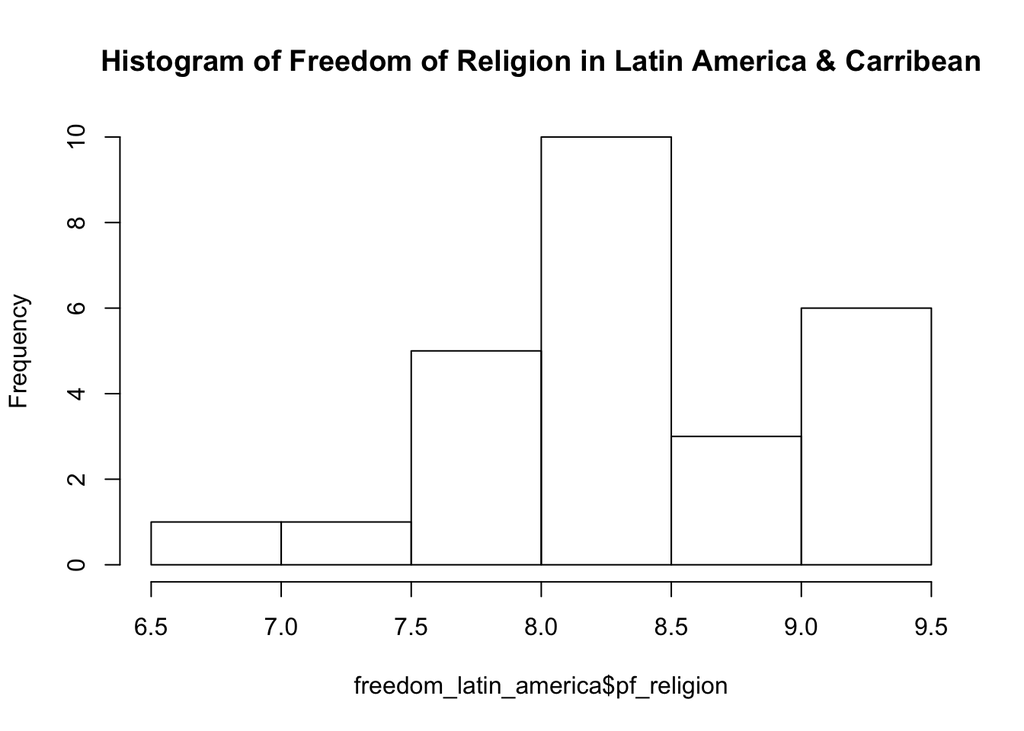

```r
#Check histogram for Latin America
hist(freedom_latin_america$pf_religion, main = "Histogram of Freedom of Religion in Latin America & Carribean")
```

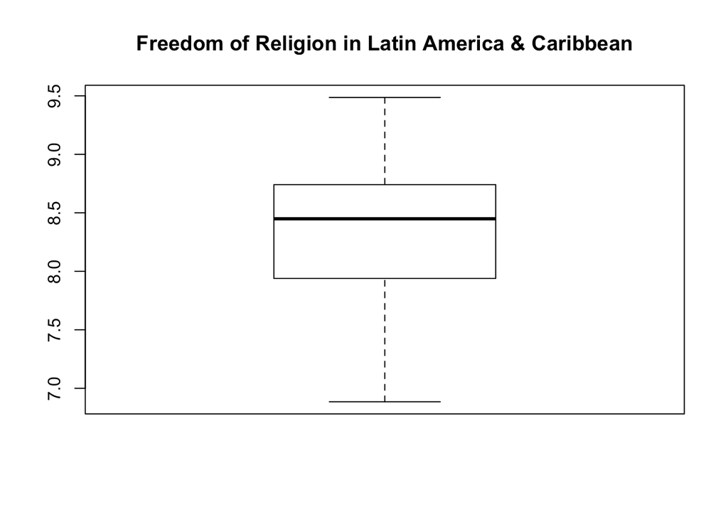

```r
#Check boxplot for Latin America
boxplot(freedom_latin_america$pf_religion, main = "Freedom of Religion in Latin America & Caribbean")
```

*Two Sample t-test*
$$H_0: \mu_1-\mu_2=0\\ H_a: \mu_1-\mu_2\neq0$$
Where $\mu_1$ is the average population personal freedom religion score for Latin America & the Carribean. $\mu_2$ is the average population personal freedom religion score for the Middle East & North Africa.

*Perform a Two Sample t-test*

```r
#Two-sample t-test
t.test(pf_religion ~ region, data = df)
```

```
##
##  Welch Two Sample t-test
##
## data:  pf_religion by region
## t = 10.187, df = 23.358, p-value = 4.569e-10
## alternative hypothesis: true difference in means is not equal to 0
## 95 percent confidence interval:
##  2.524666 3.809967
## sample estimates:
## mean in group Latin America & the Caribbean
##                                    8.398654
##    mean in group Middle East & North Africa
##                                    5.231337
```

```r
#Cohen's d
mean1 <- mean(freedom_latin_america$pf_religion, na.rm = T)
mean2 <- mean(freedom_MENA$pf_religion, na.rm = T)
sd1 <- sd(freedom_latin_america$pf_religion)
sd2 <- sd(freedom_MENA$pf_religion, na.rm = T)
cohen_d <- abs(mean1 - mean2)/sqrt((sd1^2 + sd2^2)/2)
print("Cohen's d is 3.28")
```

```
## [1] "Cohen's d is 3.28"
```

## Linear Regressions

*Linear Regression between pf_rol_criminal and pf_score*

```r
#Number 5a
#Create a multiple linear regression line using our explanatory variables pf_rol_criminal, pf_ss_homicide, pf_movement, pf_religion, pf_identity against our response variable pf_score

#Model for pf_rol_criminal
criminal_model <- with(human_freedom,pf_score ~ pf_rol_criminal)
lm_criminal <- lm(formula = criminal_model, data = human_freedom)
summary(lm_criminal)
```

```
##
## Call:
## lm(formula = criminal_model, data = human_freedom)
##
## Residuals:
##     Min      1Q  Median      3Q     Max
## -3.3593 -0.3923  0.2699  0.5291  1.5022
##
## Coefficients:
##                 Estimate Std. Error t value Pr(>|t|)
## (Intercept)      4.52477    0.28224   16.03   <2e-16 ***
## pf_rol_criminal  0.56451    0.05488   10.29   <2e-16 ***
## ---
## Signif. codes:  0 '***' 0.001 '**' 0.01 '*' 0.05 '.' 0.1 ' ' 1
##
## Residual standard error: 0.9075 on 103 degrees of freedom
##   (57 observations deleted due to missingness)
## Multiple R-squared:  0.5067, Adjusted R-squared:  0.502
## F-statistic: 105.8 on 1 and 103 DF,  p-value: < 2.2e-16
```

$$pf_{score} = 4.5248 + 0.5645*pf_{rol criminal}$$

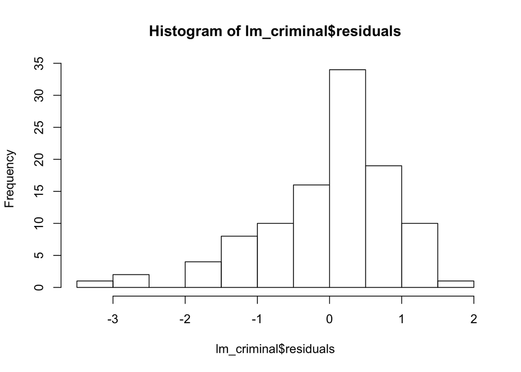

```r
#Create a histogram for pf_rol_criminal
hist(lm_criminal$residuals)
```

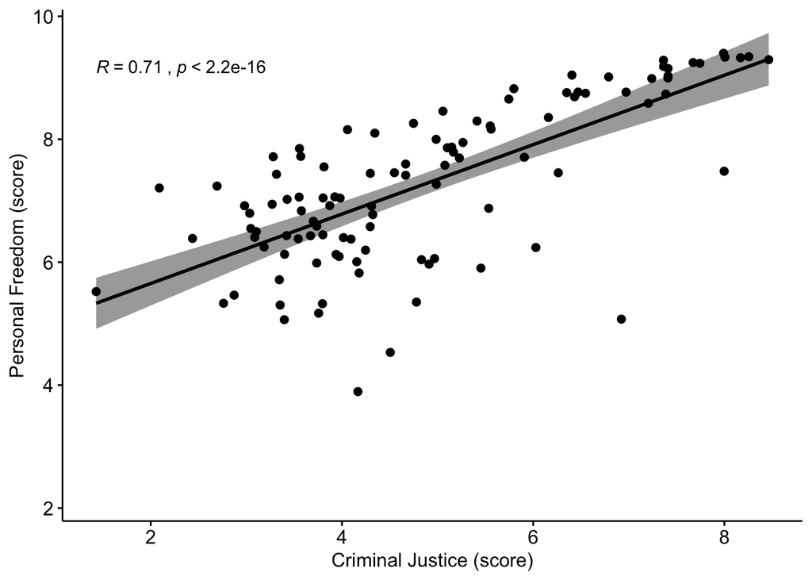

```r
#Create a scatterplot for pf_rol_criminal
ggscatter(human_freedom, x = "pf_rol_criminal", y = "pf_score",
          add = "reg.line", conf.int = TRUE,
          cor.coef = TRUE, cor.method = "pearson",
          xlab = "Criminal Justice (score)", ylab = "Personal Freedom (score)")
```

*Linear Regression between pf_ss_homicide and pf_score*

```r
#Model for pf_ss_homicide
homocide_model <- with(human_freedom,pf_score ~ pf_ss_homicide)
lm_homicide <- lm(formula = homocide_model, data = human_freedom)
summary(lm_homicide)
```

```
##
## Call:
## lm(formula = homocide_model, data = human_freedom)
##
## Residuals:
##     Min      1Q  Median      3Q     Max
## -4.7963 -0.9983  0.2497  1.1985  2.1871
##
## Coefficients:
##                Estimate Std. Error t value Pr(>|t|)
## (Intercept)     6.21492    0.33830   18.37   <2e-16 ***
## pf_ss_homicide  0.10194    0.04212    2.42   0.0166 *
## ---
## Signif. codes:  0 '***' 0.001 '**' 0.01 '*' 0.05 '.' 0.1 ' ' 1
##
## Residual standard error: 1.468 on 160 degrees of freedom
## Multiple R-squared:  0.03532,    Adjusted R-squared:  0.02929
## F-statistic: 5.859 on 1 and 160 DF,  p-value: 0.01662
```

$$pf_{score} = 6.2149 + 0.1019*pf_{ss homicide}$$

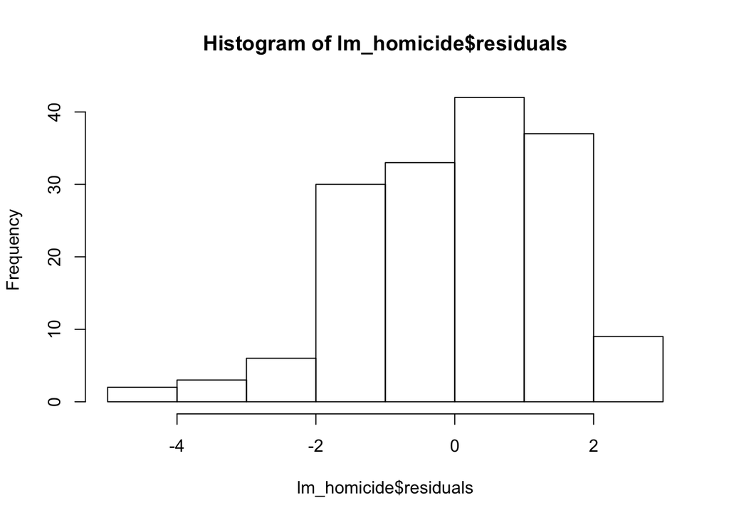

```r
#Create a histogram for pf_ss_homicide
hist(lm_homicide$residuals)
```

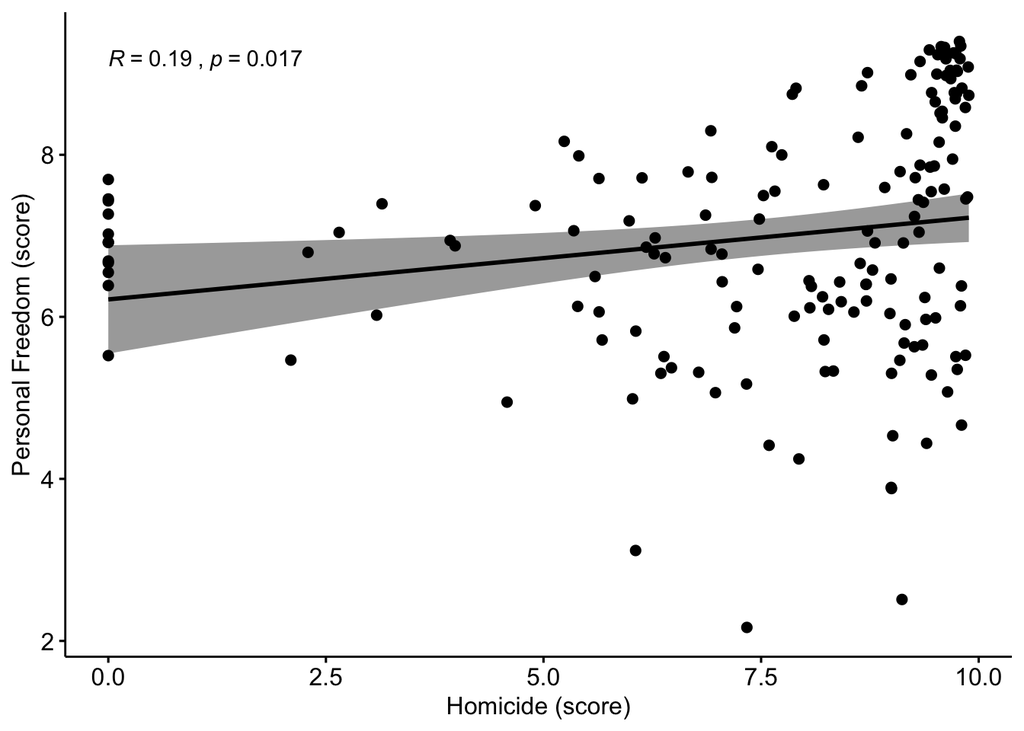

```r
#Create a scatterplot for pf_ss_homicide
ggscatter(human_freedom, x = "pf_ss_homicide", y = "pf_score",
          add = "reg.line", conf.int = TRUE,
          cor.coef = TRUE, cor.method = "pearson",
          xlab = "Homicide (score)", ylab = "Personal Freedom (score)")
```

*Linear Regression between pf_movement and pf_score*

```r
#Model for pf_movement
movement_model <- with(human_freedom,pf_score ~ pf_movement)
lm_movement <- lm(formula = movement_model, data = human_freedom)
summary(lm_movement)
```

```
##
## Call:
## lm(formula = movement_model, data = human_freedom)
##
## Residuals:
##      Min       1Q   Median       3Q      Max
## -2.28314 -0.58903  0.00824  0.74578  3.12732
##
## Coefficients:
##             Estimate Std. Error t value Pr(>|t|)
## (Intercept)  3.70428    0.21261   17.42   <2e-16 ***
## pf_movement  0.42799    0.02611   16.39   <2e-16 ***
## ---
## Signif. codes:  0 '***' 0.001 '**' 0.01 '*' 0.05 '.' 0.1 ' ' 1
##
## Residual standard error: 0.9133 on 160 degrees of freedom
## Multiple R-squared:  0.6267, Adjusted R-squared:  0.6244
## F-statistic: 268.7 on 1 and 160 DF,  p-value: < 2.2e-16
```

$$pf_{score} = 3.7043 + 0.4280*pf_{movement}$$

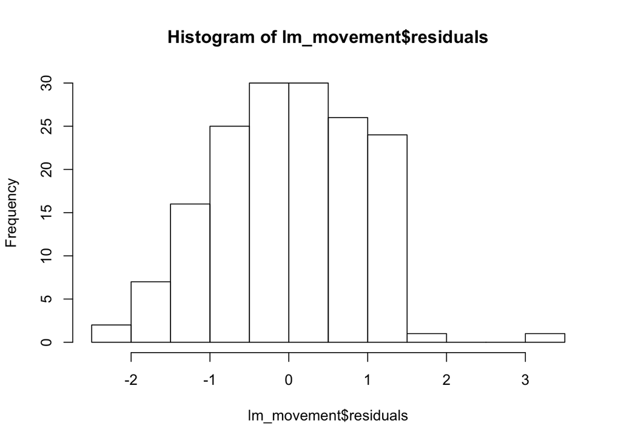

```r
#Create a histogram for pf_movement
hist(lm_movement$residuals)
```

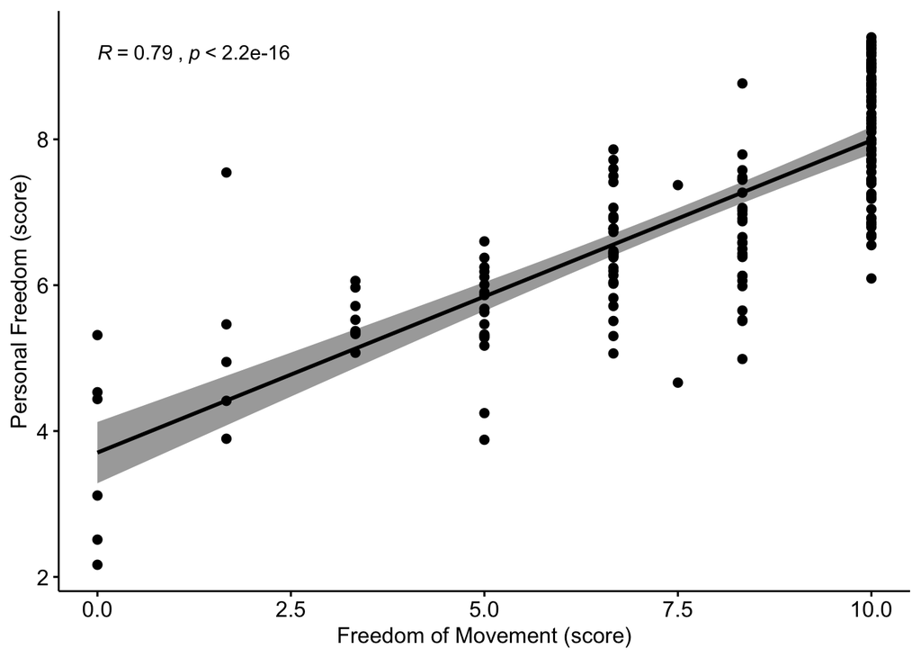

```r
#Create a scatterplot for pf_movement
ggscatter(human_freedom, x = "pf_movement", y = "pf_score",
          add = "reg.line", conf.int = TRUE,
          cor.coef = TRUE, cor.method = "pearson",
          xlab = "Freedom of Movement (score)", ylab = "Personal Freedom (score)")
```

*Linear Regression between pf_religion and pf_score*

```r
#Model for pf_religion
religion_model <- with(human_freedom,pf_score ~ pf_religion)
lm_religion <- lm(formula = religion_model, data = human_freedom)
summary(lm_religion)
```

```
##
## Call:
## lm(formula = religion_model, data = human_freedom)
##
## Residuals:
##      Min       1Q   Median       3Q      Max
## -2.94638 -0.85781 -0.07704  1.03440  2.36286
##
## Coefficients:
##             Estimate Std. Error t value Pr(>|t|)
## (Intercept)  3.22494    0.43634   7.391 7.82e-12 ***
## pf_religion  0.50688    0.05701   8.891 1.26e-15 ***
## ---
## Signif. codes:  0 '***' 0.001 '**' 0.01 '*' 0.05 '.' 0.1 ' ' 1
##
## Residual standard error: 1.185 on 159 degrees of freedom
##   (1 observation deleted due to missingness)
## Multiple R-squared:  0.3321, Adjusted R-squared:  0.3279
## F-statistic: 79.05 on 1 and 159 DF,  p-value: 1.26e-15
```

$$pf_{score} = 3.225 + 0.507*pf_{religion}$$

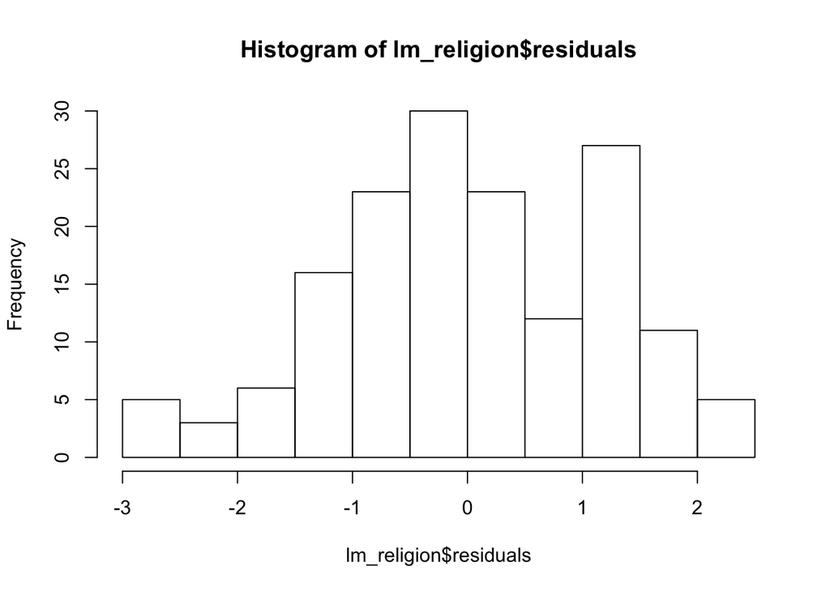

```r
#Create a histogram for pf_religion
hist(lm_religion$residuals)
```

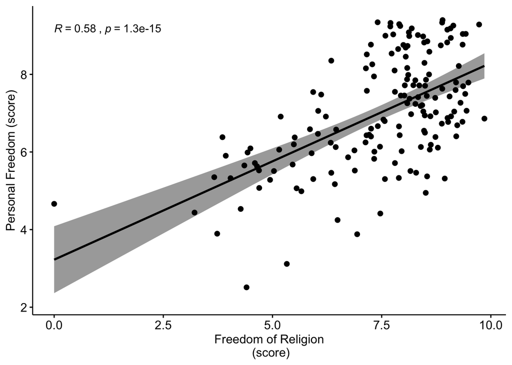

```r
#Create a scatterplot for pf_religion
ggscatter(human_freedom, x = "pf_religion", y = "pf_score",
          add = "reg.line", conf.int = TRUE,
          cor.coef = TRUE, cor.method = "pearson",
          xlab = "Freedom of Religion
 (score)", ylab = "Personal Freedom (score)")
```

*Linear Regression between pf_identity and pf_score*

```r
#Model for pf_identity
identity_model <- with(human_freedom,pf_score ~ pf_identity)
lm_identity <- lm(formula = identity_model, data = human_freedom)
summary(lm_identity)
```

```
##
## Call:
## lm(formula = identity_model, data = human_freedom)
##
## Residuals:
##      Min       1Q   Median       3Q      Max
## -2.46500 -0.61401  0.04083  0.77893  1.95381
##
## Coefficients:
##             Estimate Std. Error t value Pr(>|t|)
## (Intercept)  4.43446    0.18977   23.37   <2e-16 ***
## pf_identity  0.36555    0.02488   14.69   <2e-16 ***
## ---
## Signif. codes:  0 '***' 0.001 '**' 0.01 '*' 0.05 '.' 0.1 ' ' 1
##
## Residual standard error: 0.9754 on 160 degrees of freedom
## Multiple R-squared:  0.5742, Adjusted R-squared:  0.5716
## F-statistic: 215.8 on 1 and 160 DF,  p-value: < 2.2e-16
```

$$pf_{score} = 4.4345 + 0.3656*pf_{identity}$$

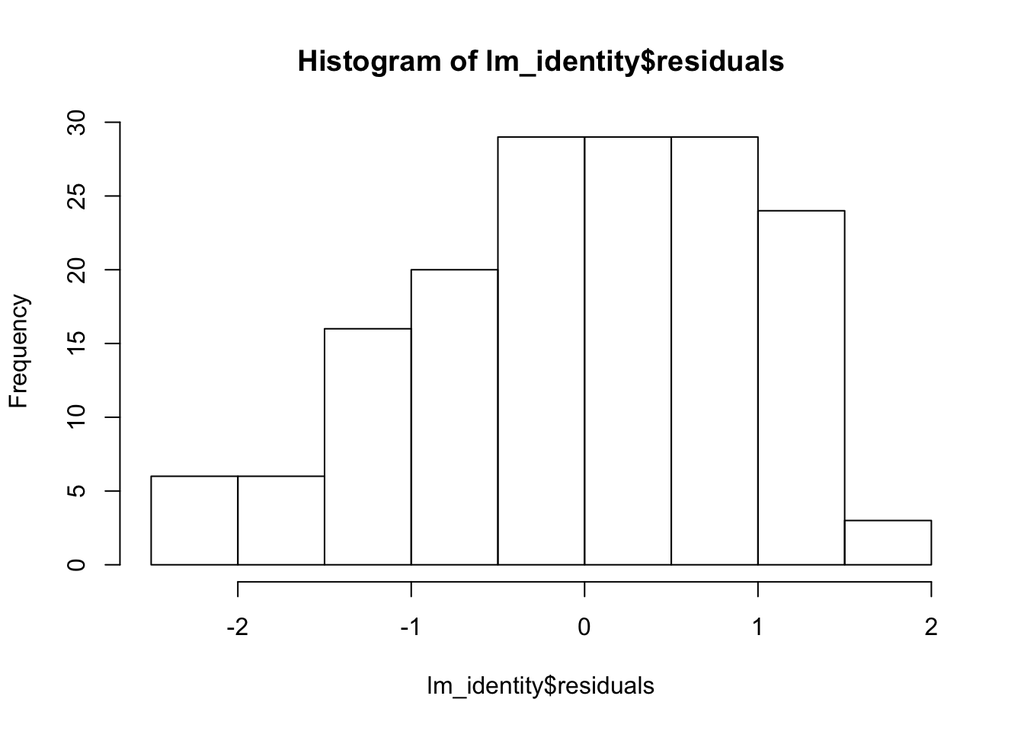

```r
#Create a histogram for pf_identity
hist(lm_identity$residuals)
```

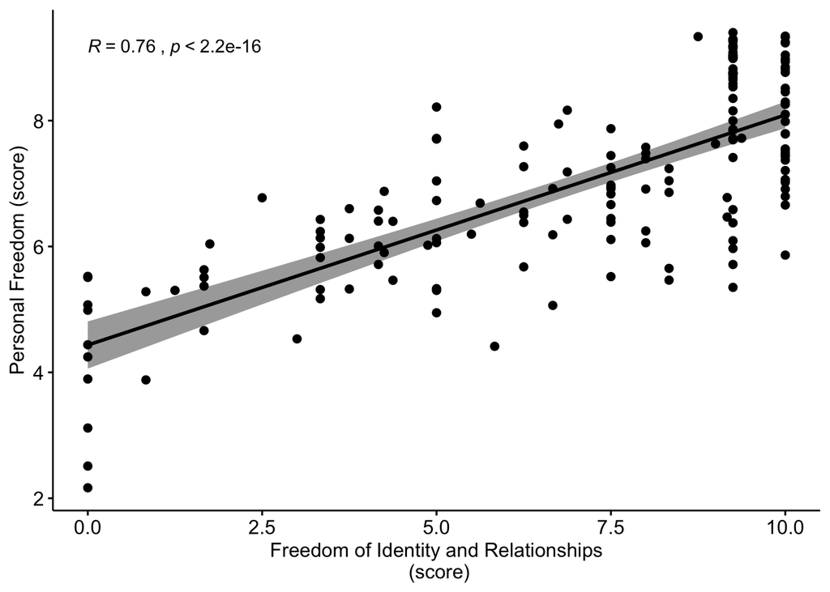

```r
#Create a scatterplot for pf_identity
ggscatter(human_freedom, x = "pf_identity", y = "pf_score",
          add = "reg.line", conf.int = TRUE,
          cor.coef = TRUE, cor.method = "pearson",
          xlab = "Freedom of Identity and Relationships
 (score)", ylab = "Personal Freedom (score)")
```

## Multiple Linear Regression

```r
#Now to create a multiple linear model for all the variables
multiple_model <- with(human_freedom,pf_score ~ pf_rol_criminal + pf_ss_homicide + pf_movement + pf_religion + pf_identity)
lm_multiple <- lm(formula = multiple_model, data = human_freedom)
summary(lm_multiple)
```

```
##
## Call:
## lm(formula = multiple_model, data = human_freedom)
##
## Residuals:
##      Min       1Q   Median       3Q      Max
## -0.81829 -0.17138  0.05817  0.18844  0.71091
##
## Coefficients:
##                 Estimate Std. Error t value Pr(>|t|)
## (Intercept)      0.72147    0.18325   3.937 0.000153 ***
## pf_rol_criminal  0.30743    0.02176  14.125  < 2e-16 ***
## pf_ss_homicide   0.08190    0.01150   7.123 1.72e-10 ***
## pf_movement      0.18492    0.01780  10.388  < 2e-16 ***
## pf_religion      0.25437    0.02443  10.412  < 2e-16 ***
## pf_identity      0.13502    0.01336  10.103  < 2e-16 ***
## ---
## Signif. codes:  0 '***' 0.001 '**' 0.01 '*' 0.05 '.' 0.1 ' ' 1
##
## Residual standard error: 0.2883 on 99 degrees of freedom
##   (57 observations deleted due to missingness)
## Multiple R-squared:  0.9521, Adjusted R-squared:  0.9497
## F-statistic:   394 on 5 and 99 DF,  p-value: < 2.2e-16
```

$$pf_{score} = 0.7215 + 0.3074*pf_{rol criminal} + 0.0819*pf_{ss homicide} + 0.1849*pf_{movement} + 0.2544*pf_{religion} + 0.1350*pf_{identity}$$

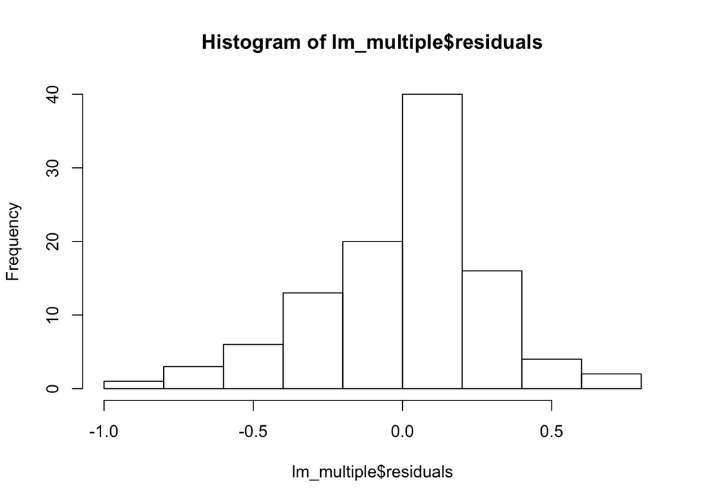

```r
#Create a histogram of the multiple linear regression model
hist(lm_multiple$residuals)
```